# DATA CLEANING PARA MINERÍA DE DATOS

J. David Ramos

marzo de 2019

## **Introducción**

La **limpieza de datos** (`Data cleaning`) es una de las etapas previas en el $KDD$ a la minería de datos. En la práctica, un analista de datos dedica mucho de su tiempo, a preparar los datos antes de realizar tarea en minería. Es muy raro que los datos en bruto (`raw data`) con los que se trabaja estén en el formato correcto, sin errores, estén completos y tengan todas las etiquetas y códigos correctos que se necesitan para la tarea.

La limpieza de datos es el proceso de transformación de datos sin procesar en datos consistentes que pueden analizarse. Está dirigido a mejorar el rendimiento de los algoritmos utilizados para la realización de tareas descriptivas o de predicción. Las acciones típicas, como la imputación o el manejo de valores atípicos, obviamente influyen en los patrones minados. Por este motivo, la limpieza de datos debe considerarse una operación estadística, que debe realizarse de manera reproducible.

## **Los datos tecnicamente consistentes**

Los **datos consistentes** son datos técnicamente correctos que son aptos para cualquier tarea de minería. Son datos en los que se eliminan, corrigen o imputan los valores perdidos, los valores especiales, los errores (obvios) y los valores atípicos.

Se puede entender que la consistencia incluye la consistencia **dentro** la observación, lo que significa que no se almacena información contradictoria en un solo registro, y la coherencia **entre** observaciones, lo que significa que los resúmenes estadísticos de diferentes variables no entran en conflicto entre sí.

Finalmente, uno puede incluir la **consistencia de conjuntos de datos cruzados**, lo que significa que el conjunto de datos que se analiza actualmente es coherente con otros conjuntos de datos que pertenecen a la misma materia.

El proceso de construir datos consistentes siempre involucra los siguientes tres pasos:

1. **Detección de una inconsistencia**: Es decir, se establece qué restricciones se violan. Por ejemplo, una variable de edad está restringida a valores no negativos.
2. **Selección de la(s) variable(s) causante(s) de la inconsistencia**. Por ejemplo, el estado civil de un niño debe ser soltero. En el caso de una violación, no está claro si la edad, el estado civil o ambos son incorrectos; lo cual es un problema bivariado
3. **Corrección de los campos que se consideran erróneos detectados en la etapa de selección**. Esto se puede hacer a través de métodos deterministas o estad´siticos

En resumen, la limpieza de datos consiste en detectar los datos erróneos o irrelevantes y descartarlos o recuperarlos para convertirlos en datos consistentes. Esto implica realizar las dos siguientes tareas:

- Detección y tratamiento de valores faltantes en una observación: (**missing data**).
- Detección y tratamiento de valores atípicos o ruidosos en una observación (**outliers data**).

Otras tareas, no menos importantes, son la detección y tratamiento de observaciones repetidas, la adecuada codificación de las observaciones y las variables (`indexación`), la selección adecuada del tipo o naturaleza de las variables para análisis, la adecuada codificación de los valores tomados por las variables, la transformación del conjunto de datos en datos con estructura rectangular (`dataframes`), entre otras.

## **Los datos**

- Suponemos una **tabla de datos yuxtapuesta** $[X|Y]$ de tamaño $(n\times p+1)$, con $n$ observaciones medidas sobre $p+1$ variables; $p$ variables son **predictoras** y $1$ variable es de respuesta.
- $X=\{X_1,X_2,...,X_p\}$: es una matriz de $p$ **variables predictoras** de $Y$, de tamaño $n\times p$
- $Y$: es un **vector de respuestas** (cuantitativa o cualitativa) de tamaño $n\times 1$
- $x_i=(x_{i1},x_{i2},x_{i3},...,x_{ip}, y_{i})$ es la $i$-ésima **observación** o **registro**, donde
- $x_{ij}$:valor de la $j$-ésima variable predictora, en la $i$-ésima observación, donde $i=1,2,3,...,n$, $j=1,2,3,...,p$, y
- $y_{i}$:valor de la variable $Y$ de respuesta para la $i$-ésima observación.

En `R`, este tipo de tablas rectangulares son estructuradas a través de **dataframes** o **arrays**.

## **Detección y tratamiento de valores faltantes**

Los **valores faltantes** (`missing values`) son valores $x_{ij}$ de la observación $x_i$ que no constan en el conjunto de datos debido a cualquier acontecimiento, como por ejemplo, errores en la transcripción de los datos, ausencia de disposición para la respuesta en un individuo observado o la imposibilidad de realizar la medición u observación misma.

### **Consecuencias de los valores faltantes:**

1. **Sesgo**: diferencia notable entre valores observados y valores no observados.
2. **Laboriosidad**: hacen el entrenamiento y el manejo de datos más complicado.
3. **Pérdida de información**: se reduce la potencia de predicción o descripción, por ejemplo.

### **Tipos de valores perdidos**

Los valores perdidos son un subconjunto del conjunto de datos y el observarlos puede obedecer a un proceso aleatorio o no aleatorio:

1. **Valores faltantes completamente no aleatorios** (*Missing Completely at Random*, $MCAR$): el proceso de la pérdida no depende de las otras variables explicativas observadas (pej. *equipo no funcionaba correctamente, el clima era terrible, la gente se enfermó, o los datos no se capturaron correctamente.*). Con los datos $MCAR$ se pierde potencia de predicción pero no bondad de ajuste
2. **Valores faltantes aleatorios** (*Missing at Random*, $MAR$): las observaciones faltantes están condicionadas por otras variables explicativas en el conjunto de datos, aunque no con la variable de respuesta (pej. *ingresos vs. baja autoestima*, *abuso sexual vs. situación social*). Con los datos $MAR$ se pierde potencia de predicción pero no bondad de ajuste
3. **Valores faltantes no aleatorios** (*Missing Not At Random* $MNAR$): si el ser un dato faltante depende del valores de variables no observadas. Con los datos $MNAR$ se pierde potencia de predicción y bondad de ajuste. Aquí lo importante no es cuantos $MNAR$ hay, sino, si estos siguen un patrón.

### **Tratamiento**:

Hay una serie de formas alternas de tratar con valores perdidos:

1. **Supresión de observaciones incompletas**: cuando el número de observaciones con valores perdidos es pequeño (menos de 5% con relación conjunto), se eliminan del conjunto dichas observaciones (**casos incompletos**) y se procede al entrenamiento.
2. **Supresión de variables**: Se suprime la(s) variable(s) que contiene(n) valores faltantes. **Poco recomendable**.
3. **Imputación simple**: Se sustituyen los valores faltantes por estimaciones de dichos valores:
1. Por un valor de tendencia central no condicionado de la variable correspondiente. (**Imputación por media, mediana, moda, etc. no condicionada**).
2. Por un valor seleccionado aleatoriamente de algún valor en una observación completa, por ejemplo por $KNN$ (**Imputación mediante una distribución no condicionada**).
3. Por un valor seleccionado aleatoriamente de la función de distribución empírica de la variable (**Imputación mediante una distribución condicionada**).
4. **Imputación mediante distribuciones no condicionadas**: se reemplaza cada valor perdido de un observación incompleta con un valor plausible obtenido a partir de observaciones semejantes a la observación incompleta.
5. **Imputación por regresión:** Ante la presencia de un patrón de valores faltantes es posible utilizar modelos de regresión para imputar información en la variable $Y$, a partir de un grupo de variables predictoras $X$ correlacionadas.

Existen muchos otros métodos de imputación, algunos de ellos muy sofisticados, basados en métodos de estimación y modelado. Se destacan: **Estimación por máxima verosimilitud**, **imputación por variables ficticias** , **imputación múltiple**, etc.

### **Detectando valores faltantes en `R`**

En `R` los valores faltantes son identificados a través de los `NA's`. La presencia de al menos un `NA` en una variable puede incluso no permitir la ejecución de una función:

```r
#Ejemplo
age <- c(23, 16, NA)
mean(age)
```

```
## [1] NA
```

```r
mean(age, na.rm = TRUE)
```

```
## [1] 19.5
```

A continación se muestra un ejemplo donde se detectan valores faltantes en un conjunto de datos simulados. Primero se construye el conjunto simulado con valores faltantes

```r
# crear semilla para la generación de números aleatorios
set.seed(555)

##generación de columnas
col1<-rep(c("M","H"),1000)
col2<-rep(c("A","B","C","D"),500)
col3<-round(rnorm(2000,mean=15,sd=2.5),3)
col4<-round(rexp(2000),3)

##Tabla inicial con datos completos
dat0<-data.frame(col1,col2,col3,col4)
dim(dat0)
```

```
## [1] 2000    4
```

```r
summary(dat0)
```

```
##  col1     col2         col3             col4
##  H:1000   A:500   Min.   : 7.186   Min.   :0.0010
##  M:1000   B:500   1st Qu.:13.246   1st Qu.:0.2805
##           C:500   Median :15.014   Median :0.6910
##           D:500   Mean   :14.952   Mean   :0.9872
##                   3rd Qu.:16.627   3rd Qu.:1.3540
##                   Max.   :23.554   Max.   :6.8860
```

```r
# Aleatoriamente crear una  un conjunto de valores fila/columna para borrar
set.seed(979)
col<-sample(ncol(dat0),1500,replace=T)
row<-sample(nrow(dat0),1500,replace=T)
missing<-data.frame(row,col)
head(missing)
```

```
##    row col
## 1   65   3
## 2  454   1
## 3 1196   3
## 4 1026   2
## 5 1130   1
## 6  353   4
```

```r
# asignar <NA's> a la celdas seleccionadas. La tabla con valores perdidos es dat1
dat1<-dat0
for(j in 1:nrow(missing))
    dat1[missing[j,1],missing[j,2]]<-NA

head(dat1)
```

```
##   col1 col2   col3  col4
## 1    M    A 14.175 0.221
## 2    H <NA> 16.259    NA
## 3    M <NA> 15.936 0.294
## 4    H    D 19.722    NA
## 5    M    A 10.550 1.485
## 6    H <NA> 17.214 6.347
```

El conjunto de datos `dat1` tiene valores faltantes, entonces la primera tarea consiste detectar la cantidad y la ubicación de dichos valores:

```r
## Hay NA's dentro del conjunto de datos?
any(is.na(dat1))
```

```
## [1] TRUE
```

```r
summary(dat1)
```

```
##    col1       col2          col3             col4
##  H   :839   A   :406   Min.   : 7.186   Min.   :0.0010
##  M   :825   B   :410   1st Qu.:13.280   1st Qu.:0.2815
##  NA's:336   C   :410   Median :15.029   Median :0.6890
##             D   :414   Mean   :14.979   Mean   :0.9819
##             NA's:360   3rd Qu.:16.651   3rd Qu.:1.3595
##                        Max.   :23.031   Max.   :6.8860
##                        NA's   :327      NA's   :345
```

**Ejercicio:** Cree una función que cuente el número de valores faltantes por columna. Denomine a esta función `totalcol.NA`. **Pista:** puede utilizar la función `apply()` y la función `is.na()`

La siguiente etapa es ubicar la posición del `NA` dentro del conjunto de datos (fila/columna). Para ésta etapa son útiles las funciones `is.na()` y `complete.cases()`

```r
#Identificar fila/columna donde está el valor pérdido (trampa)
ubic.NA<-which(is.na(dat1)==TRUE,arr.ind = TRUE); head(ubic.NA)
```

```
##      row col
## [1,]   8   1
## [2,]  14   1
## [3,]  15   1
## [4,]  16   1
## [5,]  20   1
## [6,]  49   1
```

```r
#Retorna los valores pérdidos (TRUE) dentro de cada variable
ubic.NA2<-dat1[!complete.cases(dat1),]; head(ubic.NA2)
```

```
##   col1 col2   col3  col4
## 2    H <NA> 16.259    NA
## 3    M <NA> 15.936 0.294
## 4    H    D 19.722    NA
## 6    H <NA> 17.214 6.347
## 8 <NA>    D 18.411 1.264
## 9    M <NA> 15.092    NA
```

```r
#Porcentaje de observaciones con valores faltantes dentro de los datos
incompletos<-nrow(dat1[!complete.cases(dat1),])
porcentaje<-incompletos/nrow(dat1)*100; porcentaje
```

```
## [1] 51.85
```

**Ejercicio**: Construya un gráfico adecuado que represente la proporción de valores consistentes versus la proporción de valores faltantes para cada variable del conjunto de datos.

### **Visualizando valores faltantes en `R`**

La visualización de los `NA's` dentro del conjunto de datos puede ser muy útil. Algunas librerías apropiadas para este trabajo son `Amelia` y `DataExplorer`:

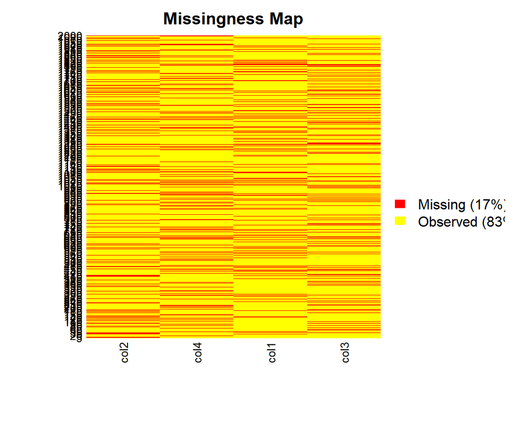

```r
#install.packages("Amelia")
library(Amelia)
#install.packages("DataExplorer")
library(DataExplorer)

#Ubicación de los NA's en el conjunto de datos (missmap{Amelia})
missmap(dat1,col=c("red","yellow"))
```

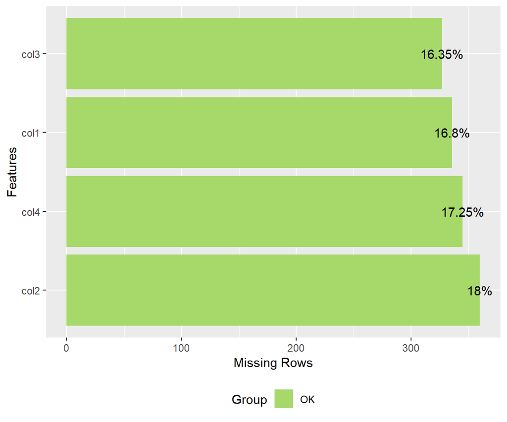

```r
#Proporción de valores faltantes por variable (plot_missing{DataExplorer})
plot_missing(dat1)
```

## **Suprimiendo observaciones con valores perdidos en `R`**

Suponiendo que la proporción de observaciones con valores perdidos dentro del conjunto de datos no es muy grande, se pueden extraer dichas observaciones. Esto se logra con la función `na.omit()`

```r
#Se extraen las observaciones incompletas generando un conjunto con sólo observaciones completas
newdata1<-na.omit(dat1)

#verificación
any(is.na(newdata1))
```

```
## [1] FALSE
```

## **Realizando imputación simple en `R`**

La imputación simple se recomienda cuando la proporción de observaciones incompletas es grande en relación a las observaciones completas. Si toman en cuenta sólo las variables cuantitativas las imputaciones para los `NA's` puede ser la media, la mediana, la trimedia o cualquier otro estadístico de centralidad de las variables en cuestión. Se recomienda la mediana, por ejemplo, cuando la distribución de la variable a imputar es muy asimétrica. En caso contrario, es adecuada la media.

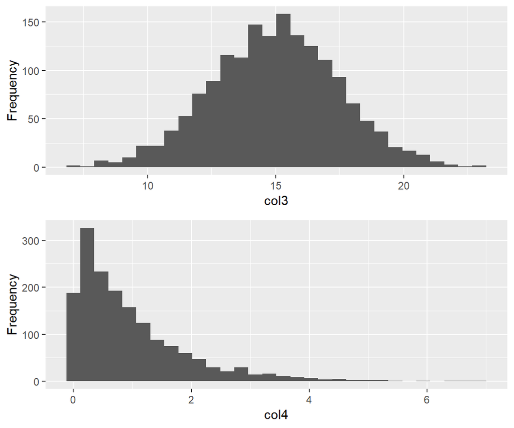

```r
# Histogramas para las variables col3 y col4 (plot_histogram{DataExplorer})
plot_histogram(dat1,ncol = 2)
```

```r
df.imp<-data.frame(col3.imp=dat1$col3,col4.imp=dat1$col4)

#Imputando la media para la columna 3
df.imp[is.na(df.imp$col3.imp),"col3.imp"] <- mean(dat1$col3, na.rm=T)
any(is.na(df.imp$col3.imp))
```

```
## [1] FALSE
```

```r
#Imputando la mediana para la columna 4
df.imp[is.na(df.imp$col4.imp),"col4.imp"] <- median(dat1$col4, na.rm=T)
any(is.na(df.imp$col4.imp))
```

```
## [1] FALSE
```

**Ejercicio.** ¿Qué criterio tendría presente para asegurar o no que la imputación fue, al menos, aceptable?

**Ejercicio.** Compare las distribuciones de frecuencias de las variables observadas y las variables imputadas ¿Qué puede observar?

**Ejercicio.** Utilice la moda para imputar los valores faltantes en las variables `col1` y `col2`

### **Imputación mediante distribuciones no condicionadas en `R`**

Es posible utilizar el algoritmo de los **K-Vecinos más próximos** para la imputación de valores faltantes mediante distribuciones no condicionadas. Se basa en buscar las $K$ observaciones completas más próximas a la observación que se desea imputar. Una vez encontradas las observaciones más cercanas se podría imputar, por ejemplo, la media o la moda de los $K$ vecinos.

La aplicación en `R` del $KNN$ para imputación se realiza a través de la función `kNN()` del paquete `VIM`. El algoritmo admite todo tipo de variables:

```r
#install.packages("VIM")
library(VIM)

# Aplicación del KNN para imputación con K=1 vecinos
imputadoknn<-VIM::kNN(data = dat1,k=1,numFun=median)
head(imputadoknn)
```

```
##   col1 col2   col3  col4 col1_imp col2_imp col3_imp col4_imp
## 1    M    A 14.175 0.221    FALSE    FALSE    FALSE    FALSE
## 2    H    A 16.259 1.082    FALSE     TRUE    FALSE     TRUE
## 3    M    B 15.936 0.294    FALSE     TRUE    FALSE    FALSE
## 4    H    D 19.722 0.151    FALSE    FALSE    FALSE     TRUE
## 5    M    A 10.550 1.485    FALSE    FALSE    FALSE    FALSE
## 6    H    D 17.214 6.347    FALSE     TRUE    FALSE    FALSE
```

```r
any(is.na(imputadoknn[,1:4]))
```

```
## [1] FALSE
```

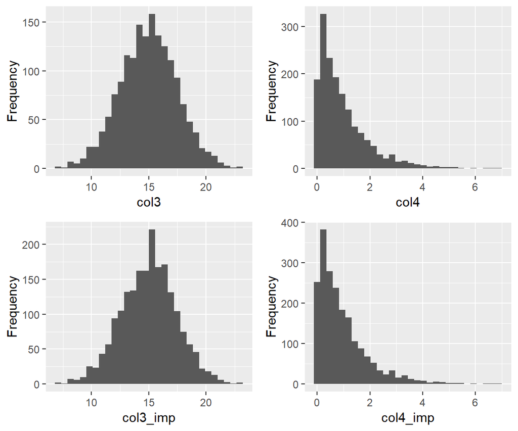

```r
plot_histogram(cbind(dat1,col3_imp=imputadoknn$col3,col4_imp=imputadoknn$col4))
```

**Ejercicio**: Realice la imputación con $K=10$ vecinos. Compare las distribuciones de las observaciones completas con las imputadas en la variables numéricas.

**Ejercicio**: Realice la imputación con $K=10$ vecinos. Compare las distribuciones de las observaciones completas con las imputadas en la variables cualitativas.

### **Realizando imputación múltiple en `R`**

La imputación múltiple se recomienda cuando la proporción de observaciones incompletas es grande en relación a las observaciones completas. En esta metodologia se toman en cuenta la información de las $X_{p-1}$ variables con más correlacionadas con la variable $X_i$ donde está el valor faltante. El proceso es iterativo y consiste en ajustar $p-1$ modelos para generar una cantidad aceptable de valores de imputación plausibles para $X_i$. Obtenidos estos conjuntos de valores, la imputación se realiza promediando los valores plausibles.

Existen muchos métodos para realizar la imputación múltiple, entre ellos se destaca el **Algoritmo MICE** (*Multivariate imputation by chained equations*) que está disponible en la librería homónima

```r
#install.packages("mice")
library(mice)


#Función para calcular número de NA's
na.number<- function(x){sum(is.na(x))}

multimp.mice<-mice(dat1,m = 5)
imputados.mice<-complete(multimp.mice)

any(is.na(imputados.mice))
```

```
## [1] FALSE
```

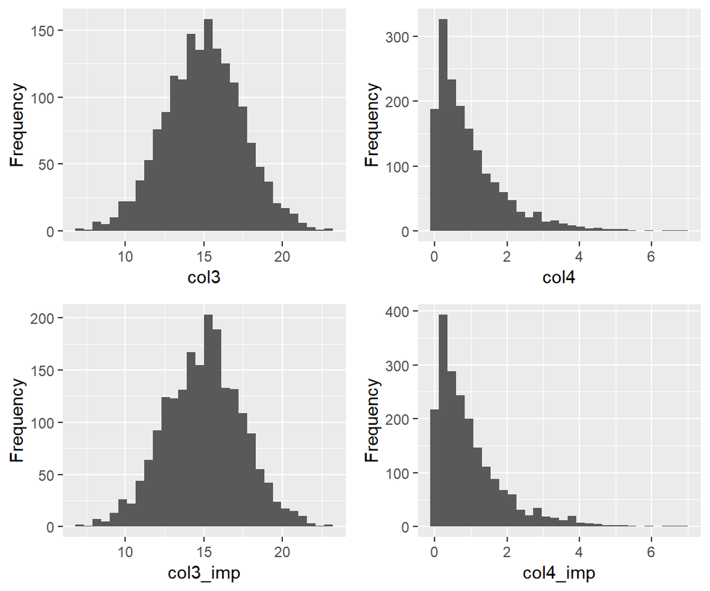

```r
plot_histogram(cbind(dat1,col3_imp=imputados.mice$col3,col4_imp=imputados.mice$col4))
```

## **Detección y tratamiento de valores atípicos**

Los **valores atípicos, anormales o extremos** (**outliers**) son valores $x_{ij}$ de la observación $x_i$ que se “alejan”, en términos de distancias, a la mayor parte de las demás observaciones sobre una misma variable continua. A mayor cantidad de observaciones en un conjunto de datos, mayor es la probabilidad de la aparición de outliers.

### **¿A qué de deben los valores atípicos?**

La presencia de outliers obedece a múltiple razones:

1. **Errores en la medición u observación** de la variable sobre el individuos.
2. **Errores en la digitación** de los datos.
3. **Casos extremos** fuera del rango común, pero verdaderos.

### **¿Por qué detectar outliers?**

1. Si son pocos, quizás no afecten los resultados en una tarea de minado (¿Qué significará pocos?)
2. En sí mismos, los outliers pueden ser interesantes: detección de fraude, de una condición (enfermedad), etc.
3. Los valores atípicos en los datos pueden distorsionar las predicciones y afectar la precisión, especialmente en las tareas de predicción y clasificación.
4. Permite centrar la atención en aquellos valores que necesitan una mayor inspección.

### **¿Cuándo un dato se considera outlier?**

1. **Es una decisión subjetiva**: no hay una regla estadística totalmente aceptada.

$$x_{ij}>3s_x \quad ó \quad x_{ij}<3s_x$$

$$x_{ij}>Q_3+1.5(IQR)\quad ó \quad x_{ij}<Q_1-1.5(IQR)$$

2. Debe primar el **concepto de un experto** en los datos para declarar o no un valor como outlier.
3. Se puede hacer la consideración de manera univariada (**valores atípicos por variable**) o de manera multivarida (**observaciones atípicas a través de las variables**).

### **Técnicas para detectar ouliers**

1. **Métodos por valores de resumen y comparación de distancias**: mínimos, máximos, cuantiles, etc.
2. **Métodos gráficos**: Boxplots, histogramas, dotplots, etc.
3. **Métodos basados en distribuciones de probabilidad**: valores cuya probabilidad de tomar un valor medio es pequeña.
4. **Métodos basados en densidades**: detección de valores alejados de grandes concentraciones de valores.

### **Tratamiento de outliers**

El tratamiento es practicamente el mismo que para los valores faltantes: detección de las observaciones, eliminación de las observaciones o imputación (**Todo bajo criterio de un experto**).

### **Detección de outliers via boxplots en `R`**

El valor $x_{ij}$ se considera un outlier cuando cumple la siguiente condición:

$$x_{ij}>Q_3+1.5(IQR)\quad ó \quad x_{ij}<Q_1-1.5(IQR)$$

Donde $Q_1$ y $Q_3$ son los cuartiles $1$ y $3$ respectivamente y $IQR$ corresponde al rango intercuartílico de la variable $X$.

A manera de ejemplo, se utiliza el conjunto de datos `ozone.csv` constituido por $366$ observaciones medidas sobre $13$ variables numéricas (no se toman en cuenta las variables cualitativas)

```r
##Se importan los datos "ozone.csv"
url<-"http://rstatistics.net/wp-content/uploads/2015/09/ozone.csv"
ozono<- read.csv(url)
dim(ozono)
```

```
## [1] 366  13
```

```r
str(ozono)
```

```
## 'data.frame':    366 obs. of  13 variables:
##  $ Month                : int  1 1 1 1 1 1 1 1 1 1 ...
##  $ Day_of_month         : int  1 2 3 4 5 6 7 8 9 10 ...
##  $ Day_of_week          : int  4 5 6 7 1 2 3 4 5 6 ...
##  $ ozone_reading        : num  3.01 3.2 2.7 5.18 5.34 5.77 3.69 3.89 5.76 6.94 ...
##  $ pressure_height      : int  5480 5660 5710 5700 5760 5720 5790 5790 5700 5700 ...
##  $ Wind_speed           : int  8 6 4 3 3 4 6 3 3 3 ...
##  $ Humidity             : int  20 NA 28 37 51 69 19 25 73 59 ...
##  $ Temperature_Sandburg : int  NA 38 40 45 54 35 45 55 41 44 ...
##  $ Temperature_ElMonte  : num  NA NA NA NA 45.3 ...
##  $ Inversion_base_height: int  5000 NA 2693 590 1450 1568 2631 554 2083 2654 ...
##  $ Pressure_gradient    : int  -15 -14 -25 -24 25 15 -33 -28 23 -2 ...
##  $ Inversion_temperature: num  30.6 NA 47.7 55 57 ...
##  $ Visibility           : int  200 300 250 100 60 60 100 250 120 120 ...
```

```r
# Se extraen las primeras tres columnas
ozono1<-ozono[,4:13]

# Se imputan los valores faltantes mediante KNN
imputacion<-VIM::kNN(data = ozono1,k=1,numFun=median)
ozono.imp<-imputacion[,1:10]
any(is.na(ozono.imp))
```

```
## [1] FALSE
```

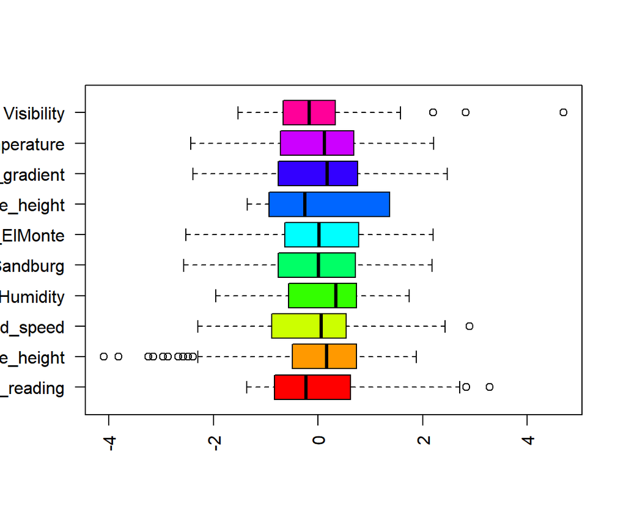

```r
#Se detectan posibles outliers de la variables imputadas vía boxplots
boxplot(scale(ozono.imp),horizontal=T,las=2,col=rainbow(10))
```

```r
#Extracción de los outliers de la variable "pressure_height"
outliers.pressure<-boxplot.stats(ozono$pressure_height)$out
outliers.pressure
```

```
##  [1] 5480 5410 5350 5480 5490 5470 5320 5420 5440 5480 5450 5500
```

**Ejercicio** ¿En qué observaciones están dichos valores dentro del conjunto `ozono1`?

### **Detección de outliers via histogramas y desviaciones estándar en `R`**

Se puede considerar que $x_{ij}$ es un outlier dentro de la variable $X$ si está a más de $k$ desviaciones estándar de la media $\overline{x}$ (por izquierda y derecha). Generalmente se toma $k=3$.

```r
#Criterio "k desviaciones estándar a la media" para detectar outliers


mean.presion<-mean(ozono.imp$pressure_height)       #presion media
sd.presion<-sd(ozono.imp$pressure_height)           #desviacion estandar
k<-seq(from=1,to=3,by=0.5)                  #k desviaciones de la media

#Con base en la función “for” se calculan los intervalos de variación para k=1, 1.5, 2, 2.5 y 3 desviaciones a la media
i<-NULL
aux1<-NULL
aux2<-NULL
aux3<-NULL
aux4<-NULL
intervalos<-matrix(ncol=2,nrow=length(k))

for(i in 1:length(k)) {
  aux1<-c(mean.presion-k[i]*sd.presion); aux2<-c(aux2,aux1)
  aux3<-c(mean.presion+k[i]*sd.presion); aux4<-c(aux4,aux3)

 intervalos[i,1]<-round(aux2[i],2)
 intervalos[i,2]<-round(aux4[i],2)
}

#Matriz con los intervalos a k=1,1.5,2,2.5 y 3 desviaciones a la media
row.names(intervalos)<-c("k=1","k=1.5","k=2","k=2.5","k=3")
colnames(intervalos)<-c("inferior","superior")
intervalos
```

```
##       inferior superior
## k=1    5646.98  5857.94
## k=1.5  5594.24  5910.67
## k=2    5541.50  5963.41
## k=2.5  5488.77  6016.15
## k=3    5436.03  6068.89
```

```r
#Se identifican qué valores están a más de 3 desviaciones de la media
outliers2<-ozono.imp$pressure_height[ozono.imp$pressure_height<intervalos[5,1] | ozono.imp$pressure_height>intervalos[5,2]]

sort(outliers2)
```

```
## [1] 5320 5350 5410 5420
```

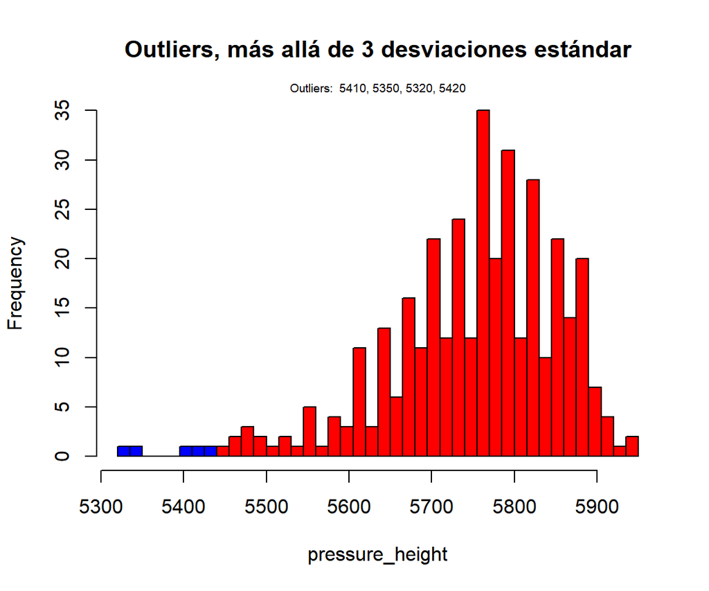

```r
#Detección via histograma
h<-hist(ozono.imp$pressure_height,breaks=seq(min(ozono.imp$pressure_height),
        max(ozono.imp$pressure_height),15),plot=FALSE)
{plot(h,col=ifelse(h$breaks<intervalos[5,1] | h$breaks>intervalos[5,2],4,2),
     main="Outliers, más allá de 3 desviaciones estándar",xlim=c(5320,5950),
     xlab="pressure_height")
mtext(paste("Outliers: ", paste(outliers2, collapse=", ")), cex=0.6)}
```

## **Tratamiento de valores atípicos**

Una vez que se identifican outliers y un experto en los datos ha confirmado que es un valor realmente extremo, se puede:

1. **Imputación simple** con media / mediana / moda, según la conveniencia, de la correspondiente variable.
2. **Imputar** a través de un $KNN$ la media / mediana / moda según la conveniencia.
3. **Capping**: Se reemplazan aquellos valores considerados outliers (por debajo y por encima) por los cuantiles del $5\%$ y $95/%$ (percentiles) respectivamente. Se puede generalizar al caso a las $k$ desviaciones estándar (incluso asumiendo un modelo: normal, chi, t, etc.)

### **Capping en `R`**

```r
# Outliers detectados vía box plot para la variable "pressure_height"
outliers.pressure
```

```
##  [1] 5480 5410 5350 5480 5490 5470 5320 5420 5440 5480 5450 5500
```

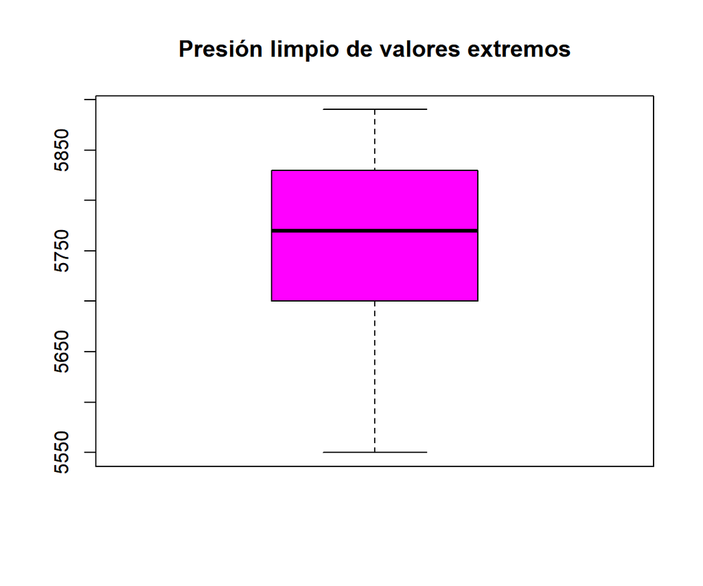

```r
#Se crea la función  "capping" para hacer los reemplazos
capping<-function(x){
    cuantiles<-quantile(x,c(0.05,0.95 ))
    x[x<cuantiles[1]]<-cuantiles[1]
    x[x>cuantiles[2]]<-cuantiles[2]
    x
}

##Se aplica el capping sobre la variable presión1 (con casos completos)
##Se tiene que los cuantiles del 5% es 5550 y del 95% es 5890

presion.cleanout<-capping(ozono.imp$pressure_height) #variable presion sin outliers

boxplot(presion.cleanout, main="Presión limpio de valores extremos",
        col="magenta")
```

## **Detección multivariada de outliers**

- Cuando se declara que un valor es atípico sobre una sola variable no se toma en cuenta su comportamiento en relacion a otras variables en los datos.
- En una tabla datos, lo que en realidad se desea es establecer si una observación se puede considerar atípica o no.
- Una detección de este tipo toma en cuenta información del conjunto de variables $\{X1,X2,...,Xp\}$, por tanto, es multivariada.
- La detección se puede lograr, por ejemplo, del algoritmo $LOF$ (`local outliers Factor`) que está basado en densidades.
- Una **densidad local** corresponde a la densidad estimada para los $k$ vecinos más cercanos a una observacion $x_i$ basada en las distancias medias entre ellos.
- Se compara densidad local de una observación con las densidades locales de sus vecinos:

**Si la densidad local de una observación es sustancialmente menor (mayor distancia en promedio) que las densidades locales observaciones vecinas similares, entonces dicha observaciónse considera outlier.**

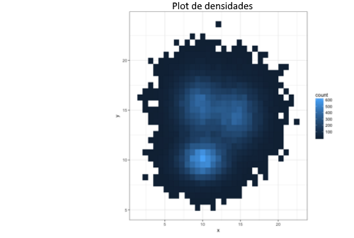

### **Detección multivariada outliers via LOF en `R`**

El algoritmo LOF se puede realizar a través de la función `lofactor{DMwR}`. La detección se hace con base en el parámetro de los $k$ vecinos. Para los $k$ vecinos se estiman las correspondientes densidades locales y aquellas observaciones con menores densidades (mayores distancias medias a sus vecinos) se identifican como outliers:

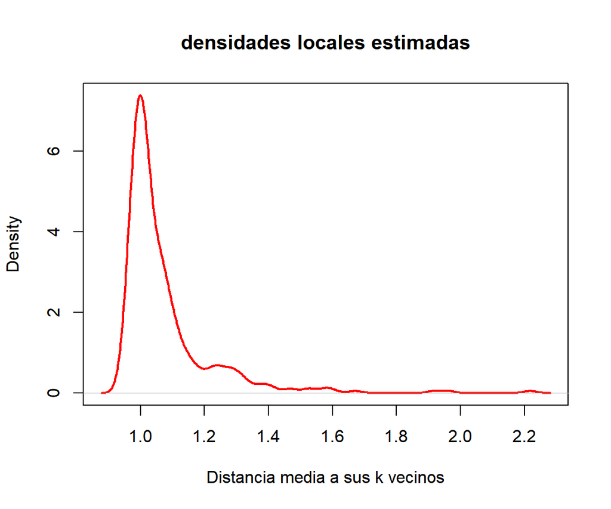

```r
##Para aplicar el algortitmo LOF hay que instalar y cargar el paquete "DMwR":
#library(DMwR)
library(DMwR)

## La función "lofactor" NO trabaja con valores faltantes. Entonces se utiliza el conjunto
## imputado "ozono.imp" via KNN
imputacion<-VIM::kNN(data = ozono1,k=1,numFun=median)
ozono.imp<-imputacion[,1:10]

#La función lofactor desarrolla el algortimo para k=1 vecinos y detecta los outliers
d.locales<-lofactor(ozono.imp, k=10) #densidades locales estimadas para las observaciones de la tabla

#plot de las densidades locales
plot(density(d.locales), main="densidades locales estimadas",col=2,lwd=2,
     xlab="Distancia media a sus k vecinos")
```

```r
#Se identifican posibles observaciones con densidades locales mayores a 1.9
d.locales[d.locales>=1.9]
```

```
## [1] 2.217180 1.960562 1.917126
```

```r
outliers3<-order(d.locales, decreasing=T)[1:length(d.locales[d.locales>=1.9])]
outliers3
```

```
## [1]  37  64 105
```

```r
# Las observaciones declaradas atípicas para k=10
ozono.imp[outliers3,]
```

```
##     ozone_reading pressure_height Wind_speed Humidity Temperature_Sandburg
## 37           2.74            5350          7       62                   30
## 64           5.20            5470          8       33                   39
## 105          6.76            5480          7       51                   46
##     Temperature_ElMonte Inversion_base_height Pressure_gradient
## 37                32.54                  1341                18
## 64                30.20                  5000                15
## 105               37.40                  2490                29
##     Inversion_temperature Visibility
## 37                  45.86         60
## 64                  30.02        500
## 105                 47.48        300
```

**Proyección de los outliers en un ACP**

Todas las observaciones de la tabla se pueden proyectar en una plano factorial generado por un **Análisis en componentes principales** (ACP). Esto se realiza a través de la función `dudi.pca()` del paquete `ade4`

```r
#install.packages("ade4")
library(ade4)

# Realiza el ACP con dos componentes principales
acp<-dudi.pca(ozono.imp,scannf =FALSE ,nf =3)

coordenadas<-data.frame("factor1"=acp$li[,1],"factor2"=acp$li[,2],
                        "N.observacion"=rownames(ozono.imp))
head(coordenadas)
```

```
##     factor1     factor2 N.observacion
## 1 4.7275839  0.38200062             1
## 2 3.3093442  0.06507403             2
## 3 2.4894161  1.97976145             3
## 4 1.3032624  1.73985577             4
## 5 0.6325558  0.46728654             5
## 6 1.1578452 -0.06230093             6
```

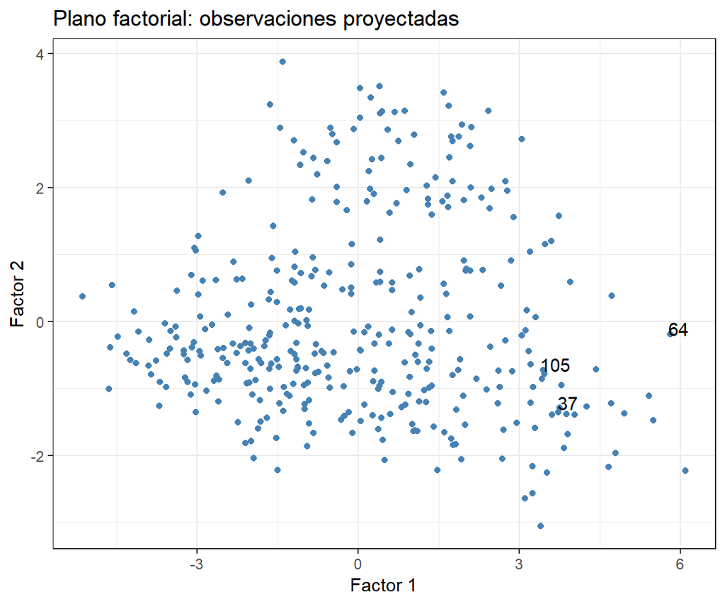

```r
newlab <- subset(coordenadas, N.observacion %in% outliers3)

# Se proyectan las observaciones sobre el primer plano factorial del ACP
library(ggplot2)

ggplot(coordenadas,aes(x=factor1, y=factor2,label=N.observacion))+
  geom_point(colour="steelblue") +
  geom_text(data = newlab , vjust = 0.1,hjust=0.1)+
    labs(y="Factor 2",
    x="Factor 1",
    title="Plano factorial: observaciones proyectadas")+
  theme_bw()
```

## **Detección de outliers por inconsistencias obvias**

Una **inconsistencia obvia** ocurre cuando una observación contiene un valor o una combinación de valores que no pueden corresponder a una situación del mundo real.

Por ejemplo:

A. La edad de una persona no puede ser negativa

B. Un hombre no puede estar embarazado,o

C. El número de hijos de una persona no puede ser un valor decimal

- La detección de tales inconsistencias se puede lograr a través de **reglas** o **contrastes de edición**. Por ejemplo, si se tiene la variable `edad` (que no puede ser negativa) se puede establecer la siguiente regla de edición:

```r
edad<-c(18,45,-56,78,0,-2,50,20)

#Regla de edición
edad.clean<-edad>=0

edad.clean
```

```
## [1]  TRUE  TRUE FALSE  TRUE  TRUE FALSE  TRUE  TRUE
```

- En el caso multivariado, se puede establecer **reglas de edición compuestas** que permiten detectar inconsistencias obvias de manera conjunta sobre cada observación:

### **Detección de inconsistencias obvias**

- El paquete `editrules` le permite definir reglas sobre conjuntos de datos categóricos, numéricos o de tipo mixto que cada observación debe obedecer:

```r
#install.packages("editrules")
library(editrules)

# Conjunto de datos juguete
edad.<-c(12,450,23,54,-3,8,89,-65,18,99)
rango.edad<-factor(c("niño","viejo","adulto","viejo","niño","niño","viejo","adulto","viejo","niño"))
estatura<-c(145,168,170,125,145,156,-110,45,45,168)
civil<-factor(c("soltero","solte","casado","casado","soltero","viudo","soltero",
                "viudo","soltero","viudo"))
t.casado<-c(0,0,2,30,0,0,0,18,-43,55)

gente<-data.frame(edad.,rango.edad,estatura,civil,t.casado); gente
```

```
##    edad. rango.edad estatura   civil t.casado
## 1     12       niño      145 soltero        0
## 2    450      viejo      168   solte        0
## 3     23     adulto      170  casado        2
## 4     54      viejo      125  casado       30
## 5     -3       niño      145 soltero        0
## 6      8       niño      156   viudo        0
## 7     89      viejo     -110 soltero        0
## 8    -65     adulto       45   viudo       18
## 9     18      viejo       45 soltero      -43
## 10    99       niño      168   viudo       55
```

```r
##Se construye un regla compuesta para edad con la función "editset"
E1<-editset(c("edad.>=0","edad.<=120"));E1
```

```
##
## Edit set:
## num1 : 0 <= edad.
## num2 : edad. <= 120
```

```r
##Se realiza el contraste en "gente" con base en la regla E1
violatedEdits(E1,dat = gente)
```

```
##       edit
## record  num1  num2
##     1  FALSE FALSE
##     2  FALSE  TRUE
##     3  FALSE FALSE
##     4  FALSE FALSE
##     5   TRUE FALSE
##     6  FALSE FALSE
##     7  FALSE FALSE
##     8   TRUE FALSE
##     9  FALSE FALSE
##     10 FALSE FALSE
```

```r
#Se construyen reglas compuestas para detectar inconsistencias t.casado y estado civil

E2<-editset(expression(
  civil %in% c("soltero","casado","viudo"),
  if (edad.>=0 && edad.<=18) rango.edad=="niño",
  estatura>0,
  if ( civil == "viudo" ) rango.edad %in% c("adulto","viejo")
))

##Se realiza el contraste en "gente" con base en la regla E2
violatedEdits(E2,dat = gente)
```

```
##       edit
## record  num1  dat3  dat4  cat2  mix3
##     1  FALSE FALSE FALSE FALSE FALSE
##     2  FALSE  TRUE FALSE FALSE FALSE
##     3  FALSE FALSE FALSE FALSE FALSE
##     4  FALSE FALSE FALSE FALSE FALSE
##     5  FALSE FALSE FALSE FALSE FALSE
##     6  FALSE FALSE FALSE  TRUE FALSE
##     7   TRUE FALSE FALSE FALSE FALSE
##     8  FALSE FALSE FALSE FALSE FALSE
##     9  FALSE FALSE FALSE FALSE  TRUE
##     10 FALSE FALSE FALSE  TRUE FALSE
```

```r
gente
```

```
##    edad. rango.edad estatura   civil t.casado
## 1     12       niño      145 soltero        0
## 2    450      viejo      168   solte        0
## 3     23     adulto      170  casado        2
## 4     54      viejo      125  casado       30
## 5     -3       niño      145 soltero        0
## 6      8       niño      156   viudo        0
## 7     89      viejo     -110 soltero        0
## 8    -65     adulto       45   viudo       18
## 9     18      viejo       45 soltero      -43
## 10    99       niño      168   viudo       55
```

### **ACTIVIDAD**

En los siguientes ejercicios se utiliza el conjunto de datos `dirty_iris`. Puede descargar este conjunto de datos desde

`https://raw.github.com/edwindj/datacleaning/master/data/dirty_iris.csv`

**Ejercicio 1. Lectura y comprobación manual**

1. Importe los datos a `R` y explore la estructura del conjunto.
2. Calcule el número y el porcentaje de observaciones que están completas.
3. ¿Los datos contienen otros valores especiales? Si lo hace, reemplazarlos con NA’s
4. Detecte todos los valores faltantes en el conjunto y establezca qué porcentaje de los datos representan.

**Ejercicio 2. Comprobando con reglas**

Además de los valores perdidos, el conjunto de datos contiene errores. Se tiene el siguiente conocimiento de los datos

- Las especies deben ser uno de los siguientes valores: setosa, versicolor o virginica.
- Todas las propiedades numéricas medidas en el conjunto deben ser positivas.
- La longitud del pétalo de cualquier flor es al menos 2 veces el ancho de su pétalo.
- La longitud del sépalo de una flor no puede exceder los 30 cm.
- Los sépalos de una flor son más largos que sus pétalos.
1. Defina estas reglas en un archivo de texto separado y léalos en R usando `editfile()` (paquete `editrules`). Imprima el objeto de restricción resultante.
2. Determine con qué frecuencia se rompe cada regla (se violan las ediciones). También resumir y describir el resultado.
3. ¿Qué porcentaje de los datos no tiene errores?
4. Averigüe qué observaciones tienen pétalos demasiado largos utilizando el resultado de las ediciones violadas.
5. Encuentre outliers en la longitud de los sépalos usando `boxplot` y `boxplot.stats`. Recupere las valores atípicos y compare con los otros valores. ¿Alguna idea de lo que podría haber pasado? Asigne a dichos valores atípicos la etiqueta NA.

**Ejercicio 3. Imputación**

1. Use la imputación $kNN$ (VIM) para imputar todos los valores faltantes en cada una de las variables con NA’s. Utilice la media de cada variable.
2. Utilice la detección de observaciones atípicas multivariada basada en el algoritmo LOF. Realice esto con $k=8$ ¿Qué debería hacer con las observaciones detectadas?